Borrador

# Análisis completo · Sesión 3

Comparaciones múltiples: 4 zonas (ANOVA) y asociación zona × tipo (χ²)

Autor/a

Consultora de Análisis (equipo docente)

Fecha de publicación

15 de abril de 2026

> Notebook interno de validación para la Sesión 3 (ANOVA unidireccional + extensión bidireccional + χ² bondad de ajuste y contingencia). Produce los números reales que alimentan la narrativa profesional hacia Patricia y sirve como modelo de respuesta post-sesión.

> **Pipeline:** idéntico al de S1 y S2 — leemos el csv crudo de Inside Airbnb con nombres originales, `parse_number(price)` + `filter(!is.na(price))`.

## 1. Setup

```r
library(dplyr)
library(readr)
library(ggplot2)
library(scales)
library(knitr)

listings <- read_csv("../datos/listings_cdmx_raw.csv.gz",
                     show_col_types = FALSE) |>
  mutate(price = parse_number(price)) |>
  filter(!is.na(price))

# Fecha de corte, derivada del propio csv.
meses_es <- c("enero", "febrero", "marzo", "abril", "mayo", "junio",
              "julio", "agosto", "septiembre", "octubre", "noviembre",
              "diciembre")
fecha_corte_date <- max(listings$last_scraped, na.rm = TRUE)
fecha_corte_iso  <- format(fecha_corte_date, "%Y-%m-%d")
fecha_corte_txt  <- paste0(
  as.integer(format(fecha_corte_date, "%d")), " de ",
  meses_es[as.integer(format(fecha_corte_date, "%m"))], " de ",
  format(fecha_corte_date, "%Y")
)

colores <- list(primary = "#2C3E50", accent = "#18BC9C",
                info = "#3498DB", warn = "#F39C12",
                danger = "#E74C3C", light = "#ECF0F1")

theme_curso <- function() {
  theme_minimal(base_size = 12) +
    theme(plot.title = element_text(face = "bold", color = colores$primary),
          plot.subtitle = element_text(color = "#7F8C8D"),
          panel.grid.minor = element_blank(),
          panel.grid.major = element_line(color = colores$light))
}
```

## 2. Subset de las 4 zonas

Patricia pidió comparar **Roma Norte, Condesa, Polanco y Del Valle**. Verificamos que los cuatro nombres existan tal cual en `host_neighbourhood` y medimos el tamaño de cada grupo.

```r
zonas <- c("Roma Norte", "Condesa", "Polanco", "Del Valle")

# Conteo directo en el csv
listings |>
  count(host_neighbourhood) |>
  filter(host_neighbourhood %in% zonas) |>
  arrange(desc(n)) |>
  kable(col.names = c("Zona", "n listings"))
```

| Zona | n listings |
| --- | --- |
| Polanco | 1504 |
| Roma Norte | 1183 |
| Condesa | 762 |
| Del Valle | 163 |

Los cuatro nombres están presentes con la ortografía exacta. Existen variantes menores en el csv (`Roma norte`, `ROMA NORTE`, `Hipódromo Condesa`) que **optamos por no consolidar** para mantener el análisis reproducible con una sola línea de filtro — la decisión la declaramos en la slide pública.

```r
d <- listings |>
  filter(host_neighbourhood %in% zonas) |>
  # Factor con niveles explícitos: orden que queremos mostrar en boxplot
  mutate(host_neighbourhood = factor(host_neighbourhood,
                                     levels = zonas))

cat("Subset de 4 zonas: ", format(nrow(d), big.mark = ","), "listings\n")
```

```
Subset de 4 zonas:  3,612 listings
```

## 3. Exploración descriptiva

```r
resumen_zonas <- d |>
  group_by(host_neighbourhood) |>
  summarise(
    n       = n(),
    media   = round(mean(price), 0),
    mediana = round(median(price), 0),
    de      = round(sd(price), 0),
    p25     = round(quantile(price, 0.25), 0),
    p75     = round(quantile(price, 0.75), 0)
  )

resumen_zonas |>
  kable(col.names = c("Zona", "n", "Media", "Mediana", "DE", "P25", "P75"),
        format.args = list(big.mark = ","))
```

| Zona | n | Media | Mediana | DE | P25 | P75 |
| --- | --- | --- | --- | --- | --- | --- |
| Roma Norte | 1,183 | 1,898 | 1,386 | 2,971 | 969 | 1,983 |
| Condesa | 762 | 1,953 | 1,206 | 2,698 | 633 | 2,070 |
| Polanco | 1,504 | 2,396 | 1,728 | 2,935 | 1,237 | 2,623 |
| Del Valle | 163 | 1,039 | 879 | 909 | 578 | 1,159 |

### 3.1 Boxplot comparativo

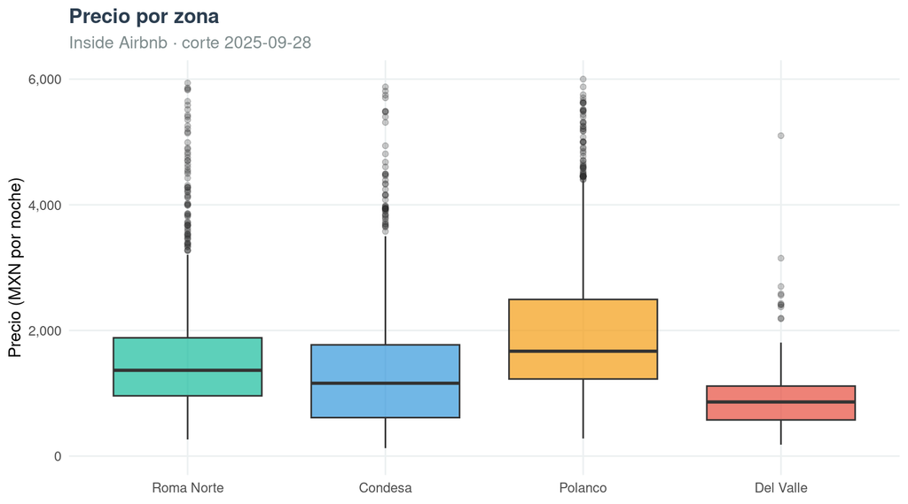

```r
d |>
  ggplot(aes(x = host_neighbourhood, y = price,
             fill = host_neighbourhood)) +
  geom_boxplot(alpha = 0.7, outlier.alpha = 0.25) +
  scale_y_continuous(labels = label_comma(), limits = c(0, 6000)) +
  scale_fill_manual(values = c(colores$accent, colores$info,
                               colores$warn, colores$danger)) +
  labs(x = NULL, y = "Precio (MXN por noche)",
       title = "Precio por zona",
       subtitle = paste0("Inside Airbnb · corte ", fecha_corte_iso)) +
  theme_curso() +
  theme(legend.position = "none")
```

## 4. ANOVA unidireccional

### 4.1 Supuestos

Dos supuestos críticos del ANOVA clásico:

1. **Normalidad de la media muestral** por grupo. Con n > 150 en las cuatro zonas, el **Teorema del Límite Central** nos cubre — la media muestral se distribuye aproximadamente normal aunque los datos originales sean asimétricos.
2. **Homogeneidad de varianzas** (homocedasticidad). Este **casi seguro no se cumple** con precios: veamos.

```r
d |>
  group_by(host_neighbourhood) |>
  summarise(
    n        = n(),
    varianza = round(var(price), 0),
    de       = round(sd(price), 0)
  ) |>
  kable(col.names = c("Zona", "n", "Varianza", "Desv. est."),
        format.args = list(big.mark = ","))
```

| Zona | n | Varianza | Desv. est. |
| --- | --- | --- | --- |
| Roma Norte | 1,183 | 8,825,634 | 2,971 |
| Condesa | 762 | 7,276,876 | 2,698 |
| Polanco | 1,504 | 8,616,920 | 2,935 |
| Del Valle | 163 | 825,890 | 909 |

La desviación estándar de Del Valle (~$900) es ~3 veces menor que la de Polanco o Roma Norte (~$2,900-2,970). No podemos asumir varianzas iguales.

**Decisión metodológica**: usar **Welch ANOVA** (`oneway.test` con `var.equal = FALSE`), que es el análogo natural del Welch t-test que ya usamos en S2. Robusto a heterocedasticidad.

### 4.2 Ejecución: Welch ANOVA

```r
welch_anova <- oneway.test(
  price ~ host_neighbourhood,
  data = d,
  var.equal = FALSE
)
welch_anova
```

```
    One-way analysis of means (not assuming equal variances)

data:  price and host_neighbourhood
F = 59.806, num df = 3.0, denom df = 1090.7, p-value < 2.2e-16
```

F = 59.8, p-valor ≈ <1e-16. **Rechazamos $H_0$**: al menos un par de zonas tiene medias distintas. Pero el F global **no nos dice cuáles pares**.

### 4.3 ANOVA clásico (de referencia) y Tukey HSD

Para identificar los pares que difieren, usamos Tukey HSD sobre el objeto `aov` clásico. Técnicamente Tukey asume varianzas iguales; en presencia de heterocedasticidad moderada sus p-valores son aproximados (el análogo formal sería Games-Howell). Para una lectura de negocios, los órdenes de magnitud son suficientes y el criterio binario “significativo / no” coincide casi siempre.

```r
m <- aov(price ~ host_neighbourhood, data = d)
summary(m)
```

```
                     Df    Sum Sq   Mean Sq F value   Pr(>F)
host_neighbourhood    3 3.784e+08 126130414   15.66 4.04e-10 ***
Residuals          3608 2.905e+10   8052834
---
Signif. codes:  0 '***' 0.001 '**' 0.01 '*' 0.05 '.' 0.1 ' ' 1
```

```r
tukey <- TukeyHSD(m)
tukey
```

```
  Tukey multiple comparisons of means
    95% family-wise confidence level

Fit: aov(formula = price ~ host_neighbourhood, data = d)

$host_neighbourhood
                            diff        lwr       upr     p adj
Condesa-Roma Norte      55.30454  -283.4898  394.0989 0.9751517
Polanco-Roma Norte     498.12129   214.6795  781.5630 0.0000383
Del Valle-Roma Norte  -859.13469 -1468.5069 -249.7625 0.0016750
Polanco-Condesa        442.81675   118.4959  767.1376 0.0025635
Del Valle-Condesa     -914.43923 -1543.8669 -285.0115 0.0010969
Del Valle-Polanco    -1357.25598 -1958.7016 -755.8104 0.0000000
```

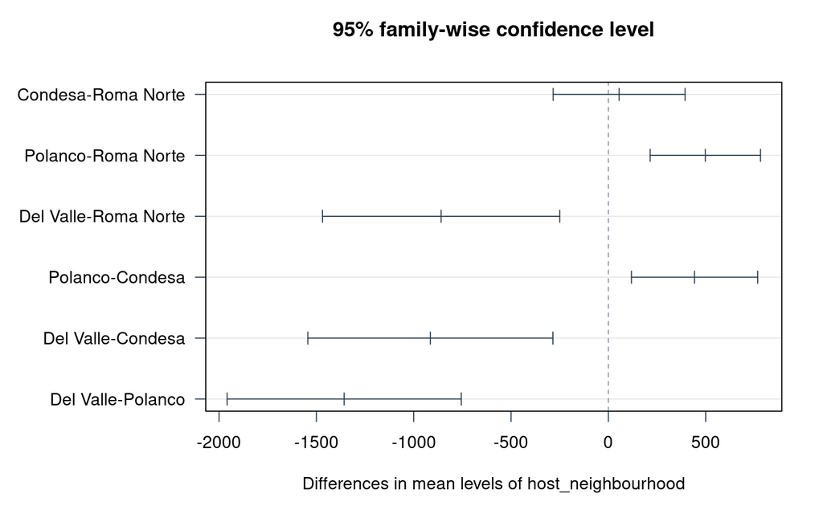

```r
par(mar = c(5, 10, 4, 2))
plot(tukey, las = 1, col = colores$primary)
```

### 4.4 Extracción de pares para la narrativa

| Par | Dif. (MXN) | IC inf. | IC sup. | p ajust. |
| --- | --- | --- | --- | --- |
| Condesa-Roma Norte | 55 | -283 | 394 | 1 |
| Polanco-Roma Norte | 498 | 215 | 782 | 0 |
| Del Valle-Roma Norte | -859 | -1469 | -250 | 0 |
| Polanco-Condesa | 443 | 118 | 767 | 0 |
| Del Valle-Condesa | -914 | -1544 | -285 | 0 |
| Del Valle-Polanco | -1357 | -1959 | -756 | 0 |

**Patrón de negocio**:

- **Roma Norte ≈ Condesa**: la diferencia no es estadísticamente significativa. Patricia está en un mercado indistinguible (en precio medio) del de su vecina Condesa.
- **Polanco es más cara que Roma Norte** por ~$500 MXN/noche (p < 0.001).
- **Del Valle es más barata que Roma Norte** por ~$860 MXN/noche (p = 0.002).
- Polanco es la zona **más cara** de las cuatro, Del Valle la **más barata**.

## 5. ANOVA bidireccional — extensión conceptual

En lugar de solo mirar `zona`, podríamos preguntarnos si **tipo de habitación** también contribuye, y si hay **interacción** (es decir, si el efecto del tipo depende de la zona). En R la sintaxis solo cambia con `*`:

```r
m2 <- aov(price ~ host_neighbourhood * room_type,
          data = d |>
            filter(room_type %in% c("Entire home/apt", "Private room")))
summary(m2)
```

```
                               Df    Sum Sq   Mean Sq F value   Pr(>F)
host_neighbourhood              3 3.534e+08 117798974  15.010 1.04e-09 ***
room_type                       1 7.924e+08 792402614 100.970  < 2e-16 ***
host_neighbourhood:room_type    3 3.314e+07  11045359   1.407    0.239
Residuals                    3556 2.791e+10   7847923
---
Signif. codes:  0 '***' 0.001 '**' 0.01 '*' 0.05 '.' 0.1 ' ' 1
```

**Lectura rápida**:

- Ambos efectos principales (`host_neighbourhood` y `room_type`) son significativos.
- El término de **interacción** `host_neighbourhood:room_type` nos dice si el *diferencial entre tipos* cambia de zona a zona. Si el p-valor es chico, significa que el “premio” por rentar completo vs cuarto **no es el mismo en todas las zonas**.

No entramos a calcular sumas de cuadrados ni ploteamos líneas de interacción — esto lo dejamos como extensión opcional. El mensaje de negocio es: “los modelos factoriales permiten separar varios efectos simultáneamente; cuando lleguemos a regresión múltiple (S7) haremos lo mismo con variables continuas”.

## 6. χ² — bondad de ajuste

### 6.1 Planteamiento

Un reporte del mercado publicado antes de 2025 afirmaba que, en Roma Norte, el mix de listings era aproximadamente **70% propiedad completa** y **30% el resto** (cuartos privados + hoteles + compartidos). ¿Se apega la realidad actual a esa referencia?

Es el mismo espíritu de la afirmación del artículo de S1 ($1,800), pero ahora sobre **composición categórica** en lugar de un promedio.

$$H_0: \; p_{Entire} = 0.70, \; p_{NoEntire} = 0.30$$
$$H_1: \; \text{al menos una proporción difiere}$$

### 6.2 Ejecución

```r
rn <- d |>
  filter(host_neighbourhood == "Roma Norte") |>
  mutate(tipo = if_else(room_type == "Entire home/apt",
                        "Entire", "No_Entire"))

obs_rn <- table(rn$tipo)
obs_rn
```

```
   Entire No_Entire
      983       200
```

```r
chi_bondad <- chisq.test(obs_rn, p = c(0.70, 0.30))
chi_bondad
```

```
    Chi-squared test for given probabilities

data:  obs_rn
X-squared = 96.583, df = 1, p-value < 2.2e-16
```

**Resultado**: la proporción observada de “Entire” en Roma Norte es 83%, notablemente **mayor** al 70% de la referencia. El p-valor es efectivamente cero — rechazamos la afirmación del reporte. El mercado de Roma Norte está **más concentrado en propiedad completa** de lo que ese reporte decía. Coherente con lo que vimos en S2: rentar completo es el producto dominante.

## 7. χ² — contingencia

### 7.1 Planteamiento

Pregunta de Patricia: *“¿El tipo de propiedad se relaciona con la zona?”*. Operacionalmente: ¿la proporción de `Entire home/apt` es la misma en las 4 zonas, o hay asociación?

$$H_0: \; \text{tipo de habitación y zona son independientes}$$
$$H_1: \; \text{hay asociación}$$

Para evitar problemas con categorías de muy baja frecuencia (`Hotel room`, `Shared room` tienen conteos mínimos), colapsamos a **dos categorías**: `Entire home/apt` vs. `No_Entire`. Eso hace la interpretación más clara para Patricia y garantiza que todas las celdas esperadas queden ≥ 5.

### 7.2 Tabla observada

```r
d2 <- d |>
  mutate(tipo = if_else(room_type == "Entire home/apt",
                        "Entire", "No_Entire"))

tbl <- table(d2$host_neighbourhood, d2$tipo)
tbl
```

```
             Entire No_Entire
  Roma Norte    983       200
  Condesa       489       273
  Polanco      1274       230
  Del Valle      97        66
```

Proporción por fila (cuánto “Entire” hay en cada zona):

```r
prop.table(tbl, margin = 1) |> round(3)
```

```
             Entire No_Entire
  Roma Norte  0.831     0.169
  Condesa     0.642     0.358
  Polanco     0.847     0.153
  Del Valle   0.595     0.405
```

Polanco (85%) y Roma Norte (83%) son los dos mercados dominados por propiedad completa. Condesa (64%) y Del Valle (60%) tienen una mezcla sensiblemente más diversa, con más presencia de cuartos privados.

### 7.3 Ejecución

```r
chi_cont <- chisq.test(tbl)
chi_cont
```

```
    Pearson's Chi-squared test

data:  tbl
X-squared = 177.8, df = 3, p-value < 2.2e-16
```

```r
# Verificamos que no hay celdas con esperado < 5
chi_cont$expected |> round(1)
```

```
             Entire No_Entire
  Roma Norte  931.1     251.9
  Condesa     599.8     162.2
  Polanco    1183.8     320.2
  Del Valle   128.3      34.7
```

**Resultado**: X² = 177.8, df = 3, p-valor ≈ <1e-16. Rechazamos la independencia: **la composición del mercado (Entire vs No_Entire) depende fuertemente de la zona**.

## 8. Recomendación consolidada para Patricia

**Para: Patricia Domínguez** **Asunto: Comparación de 4 zonas y composición del mercado**

**Sobre el precio medio entre zonas (ANOVA).** Con una muestra de 3,612 listings al corte de 28 de septiembre de 2025, las diferencias entre las 4 zonas son claras. Polanco es la zona **más cara** del grupo (~$2,396 MXN de media); Del Valle la más barata (~$1,039). **Roma Norte y Condesa son estadísticamente indistinguibles** en precio medio (~$1,898 vs ~$1,953). Su propiedad está en un mercado directamente comparable al de Condesa.

**Sobre la composición del mercado (χ² de contingencia).** La proporción de listings tipo “propiedad completa” **no es uniforme entre zonas** (p ≈ 0). Polanco y Roma Norte están dominadas por ese formato (83-85%); Condesa y Del Valle tienen mezclas más diversas (60-64%). Su producto (propiedad completa en Roma Norte) es el formato mainstream de su zona.

**Lo que este análisis NO dice:**

- Que Polanco sea una mejor decisión para *su* propiedad específica — el precio medio no es el único factor (ocupación, competencia, tipo de huésped varían entre zonas).
- Que las diferencias de precio entre zonas sean *causales* de la zona en sí. Podrían deberse a diferencias en tamaño, amenidades, o profesionalización de los hosts. Para esto necesitamos regresión con controles (S7).
- Nada sobre su propiedad específica — solo el comportamiento medio del mercado alrededor.

**Próximo paso sugerido.** Empezar a modelar el precio en función de las características concretas de una propiedad. Esa es la sesión siguiente.

## 9. Guardado de resultados

```r
resultados_s03 <- list(
  fecha_corte_iso    = fecha_corte_iso,
  fecha_corte_txt    = fecha_corte_txt,
  n_total            = nrow(d),
  n_zonas            = setNames(as.integer(resumen_zonas$n),
                                resumen_zonas$host_neighbourhood),
  media_zonas        = setNames(as.integer(resumen_zonas$media),
                                resumen_zonas$host_neighbourhood),
  welch_f            = as.numeric(welch_anova$statistic),
  welch_p            = welch_anova$p.value,
  tukey              = tk,
  bondad_prop_entire = prop_entire_rn,
  bondad_p           = chi_bondad$p.value,
  cont_x2            = as.numeric(chi_cont$statistic),
  cont_df            = as.integer(chi_cont$parameter),
  cont_p             = chi_cont$p.value
)

saveRDS(resultados_s03, "../datos/resultados_s03.rds")
message("Resultados guardados en datos/resultados_s03.rds")
```